# Homework 1

Gaurav Chawla

Jan 26 , 2018

*For all questions involving histograms, choose a sensible binwidth and breakpoints, unless otherwise indicated.*

### 1. Income

1. Describe in detail the features you observe in the boxplots below, plotted with data from the *ex0525* dataset, **Sleuth3** page. (see page 29 in *Graphical Data Analysis in R* for a list of features to concentrate on, and the numbered list on the bottom of page 43 for an example of how to describe features of a graph in words.) [5 points]

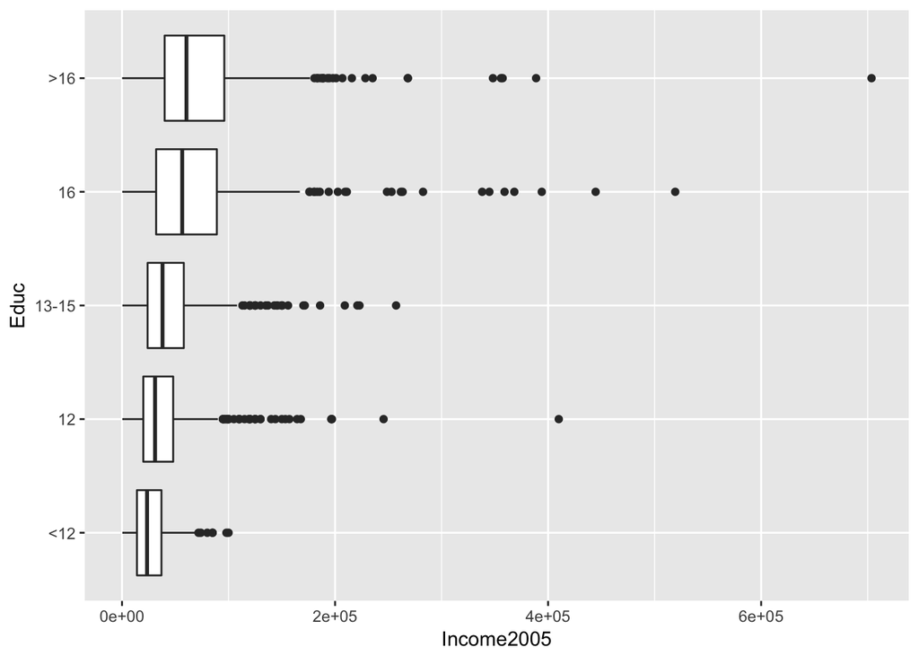

```r
#install.packages("Sleuth3")
library(Sleuth3)
library(tidyverse)

# convert Educ from an integer to a factor, and make "<12" the first factor level
mydata <- ex0525 %>%
  dplyr::mutate(Educ = forcats::fct_relevel(Educ, "<12"))

ggplot(mydata, aes(Educ, Income2005)) +
  geom_boxplot() +
  coord_flip()   # for horizontal boxplots
```

*Answer :*

1. The Median income is shifting towards the left as the number of years of education decrease. Hence it can be infered that more number of years of education may lead to higher income.
2. The variance in the income levels increase with the incease in the number of years of education.
2. Plot a histogram of the `Income2005` variable in the dataset referenced in part a). [3 points]

```r
#     hist(mydata$Income2005, col = "lightblue",
#     main = "Income Distribution", las = 1,
#     xlab = "Income")
```

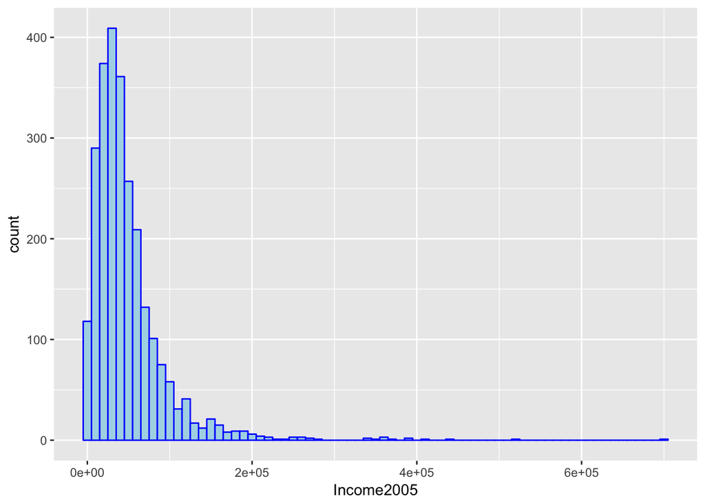

```r
  ggplot(mydata, aes(Income2005 )) +
  geom_histogram(binwidth=10000, boundry= 10, color = "blue", fill = "lightblue" )
```

3. Use `+facet_wrap(~Educ)` to facet the histogram on education level. [3 points]

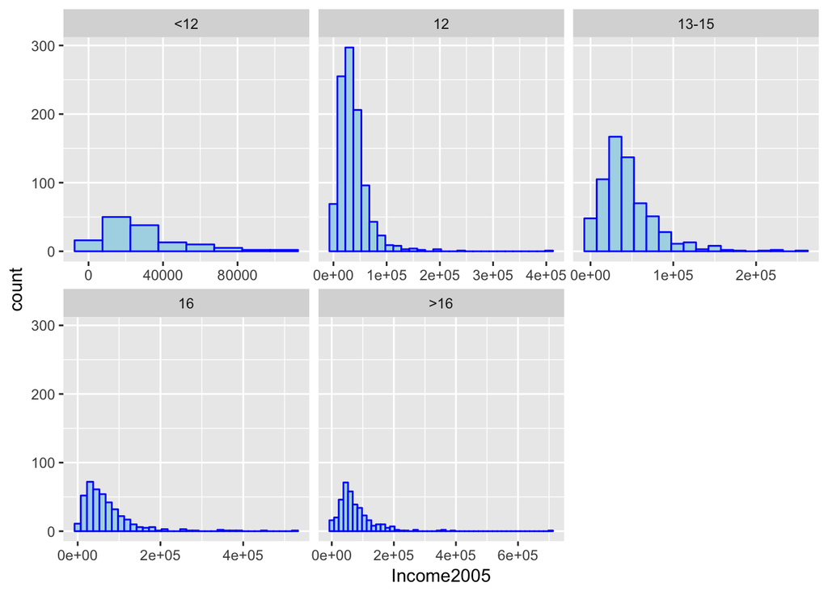

```r
  ggplot(mydata, aes(Income2005 )) +
  geom_histogram(binwidth=15000, boundry= 10, color = "blue", fill = "lightblue" )+
  facet_wrap(~Educ, scales = 'free_x')
```

4. What do you learn from the histograms that wasn’t apparent in the boxplots from question 1? [3 points]

*Answer :*

1. Histogram shows us the concentration of the data at various income levels .The shape of the data is realy clear using an historgram.
2. We are able to tell the number of records at each income level . THe interquartile ranges in box plot do not give a sense of how many records are present within a given rage ( say between 50% to 75 % )
3. We get a sense of how many records are present at each education segment .For example 12 years of education has more number of records than <12 years of education. This is not clear from boxplots.

### 2. Respiratory Rates

1. Plot right closed and right open histograms for each of the two variables in the *ex0824* dataset in the **Sleuth3** package using default binwidths and breaks. (4 histograms in total). [4 points]

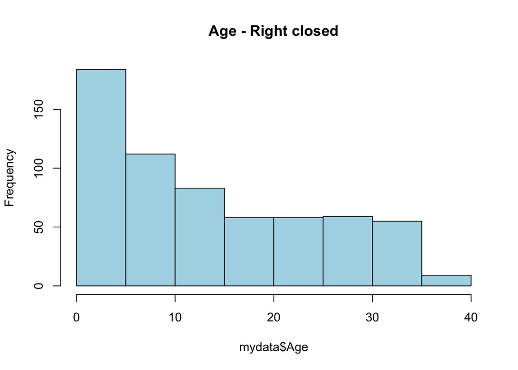

```r
mydata <- ex0824

hist(mydata$Age, col = "lightblue" , right = TRUE, main = "Age - Right closed")
```

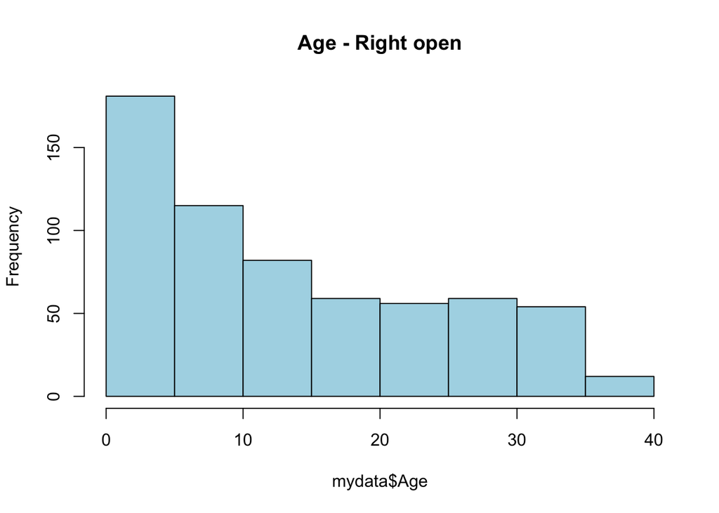

```r
hist(mydata$Age, col = "lightblue" , right=FALSE , main = "Age - Right open" )
```

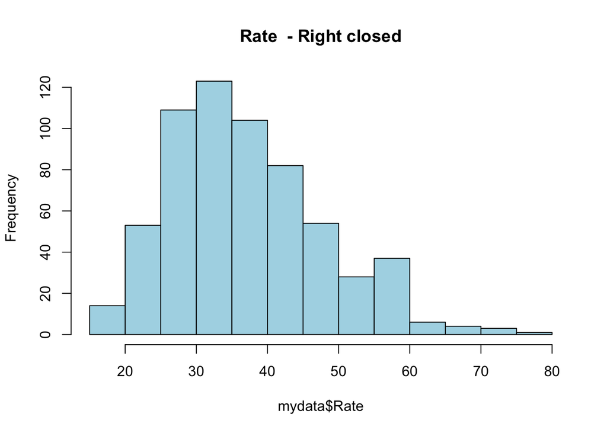

```r
hist(mydata$Rate, col = "lightblue" , right=TRUE ,main = "Rate  - Right closed"  )
```

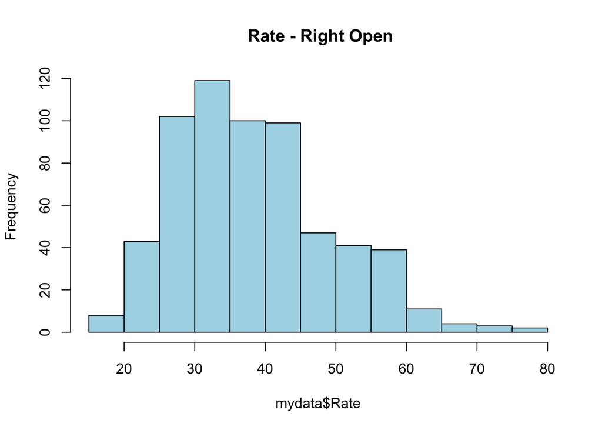

```r
hist(mydata$Rate, col = "lightblue" , right=FALSE  , main = " Rate - Right Open")
```

2. For which variable, `Age` or `Rate`, do the two versions differ more? Why? [3 points]

*Answer :*

The variable ‘Rate’ differs more . The reason is that rate has more integer values . There are many values that fall on the boundry of the default bin width of 5 . When the value fall on the bin- boundry of the histogram the “Right closed” version of the Histogram includes that value in the bin to the left . Whereas in the “Right Open” version that value is included in the bin to the right of the value ( which is more natural way of representing the data).

3. Redraw the `Age` histograms with different parameters so that the right closed and right open versions are identical. [3 points]

Redrawing the Rate paramter since it shows the more difference between rigt closed and right open

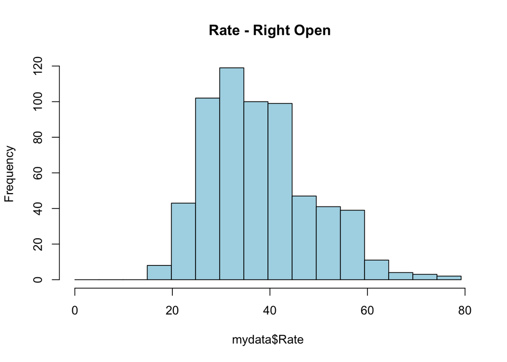

```r
  hist(mydata$Rate, col = "lightblue" , right=FALSE  ,breaks = seq(0 , 80, 4.95 ),  main = " Rate - Right Open")
```

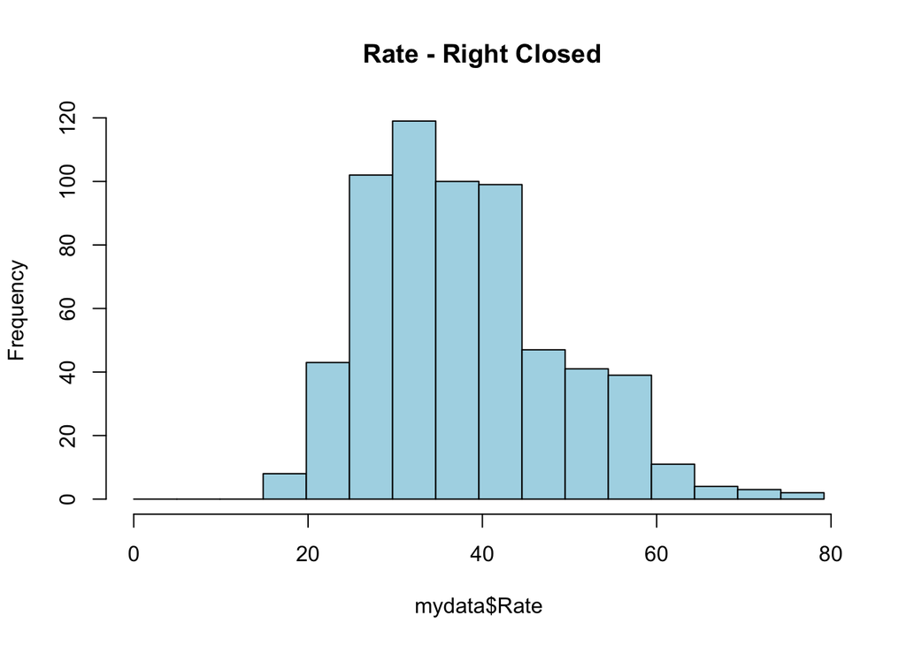

```r
  hist(mydata$Rate, col = "lightblue" , right=TRUE  ,breaks = seq(0 , 80, 4.95 ), main = " Rate - Right Closed")
```

### 3. Movie budgets

Are there rounding patterns in the `budget` variable of the *movies* in the **ggplot2movies** package? If so, what are the patterns? (Note: according to the textbook this dataset is in the **ggplot2** package, but it has since been moved to a separate package.) Support your conclusions with graphical evidence. You are encouraged to break the variable down into different budget ranges and consider them separately. [8 points]

*Answer* :

There are rounding patterns in the budget variable .

After filtering our reords with budget = NA OR budget = $ 0 , divide the budget variable into various buckets of dollar value

1. Budget between : 0 to 10 K:

Observe that the data is concentrated on round numbers in the increments of thousands.e.g. 1000, 2000 …till 10,000.

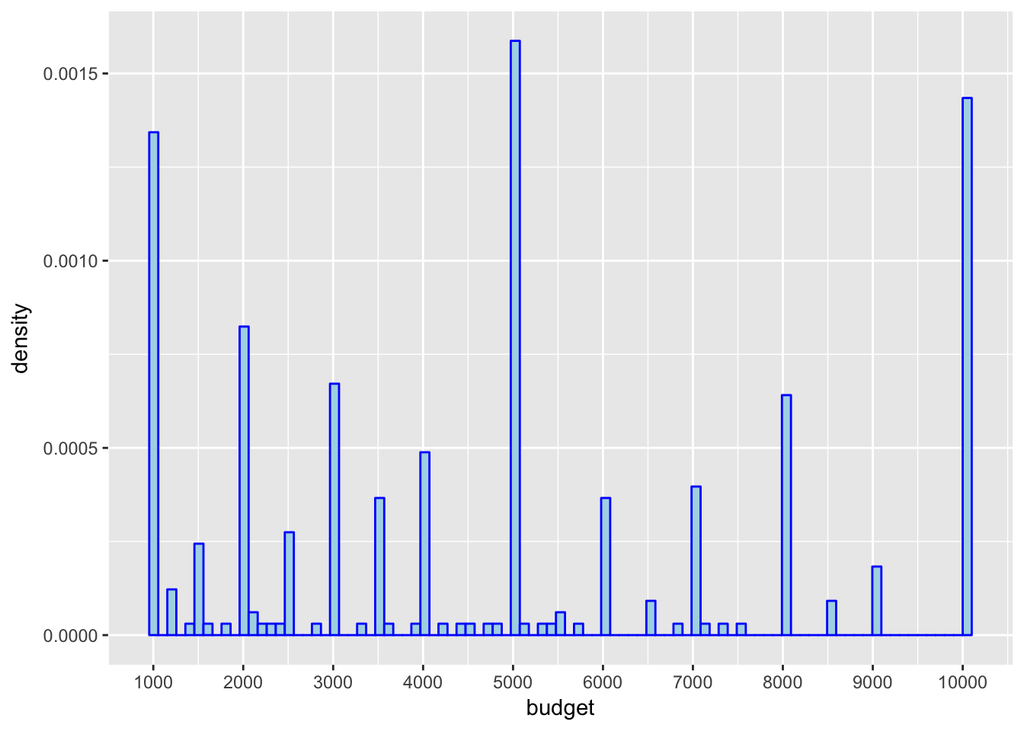

```r
library("ggplot2movies")

#filtering out NA
#plotting only budget between $0 and $10,000

mydata <- filter (movies , movies$budget != 'NA')
mydata <- filter (mydata , mydata$budget >0)
mydata <- filter (mydata , mydata$budget <= 10000)

 ggplot(mydata, aes(budget )) +
 geom_histogram(binwidth=100.5, boundry= 10, color = "blue", fill = "lightblue", aes(y=..density..) ) +
        scale_x_continuous(breaks = seq(0, 10000, 1000) )
```

2. Budget between : 10 K and 100 K:

Observe that the data is concentrated on round numbers of 5 thousands. e.g 10 , 15, 20..till 100 thousand.

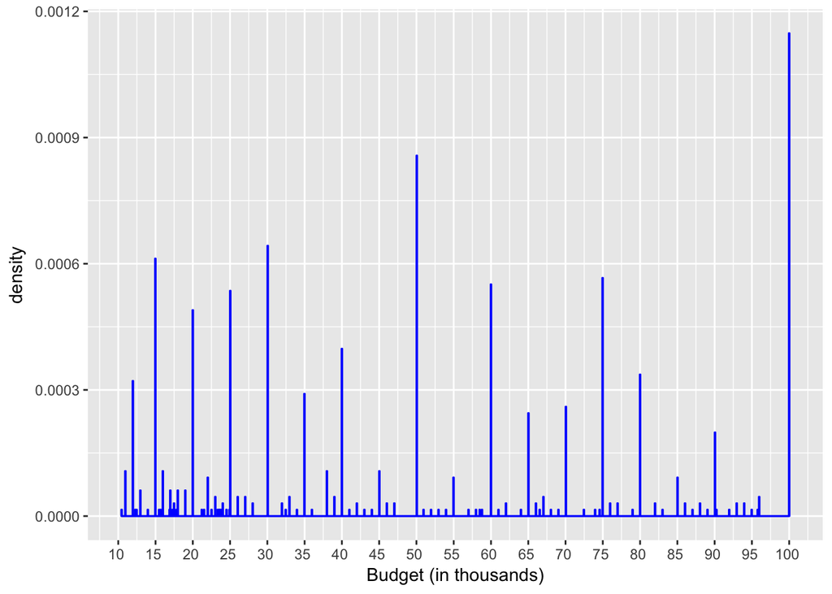

```r
#filtering out NA
#plotting only budget between $10,000 and $100,000
mydata <- filter (movies , movies$budget != 'NA')
mydata <- filter (mydata , mydata$budget >10000)
mydata <- filter (mydata , mydata$budget <= 100000)

 ggplot(mydata, aes(budget )) +
 geom_histogram(binwidth=100.5, boundry= 10, color = "blue", fill = "lightblue",   aes(y=..density..) ) +
scale_x_continuous( name = "Budget (in thousands)",labels=scales::unit_format(unit = "",1e-3), breaks = seq(10000, 100000, 5000) )
```

3. Budget between : 100 k and 1 MM:

Observe that the data is concentrated on round numbers of 50 thousands. e.g 100 , 150, 200, 250 thousand …till 1,000,000.

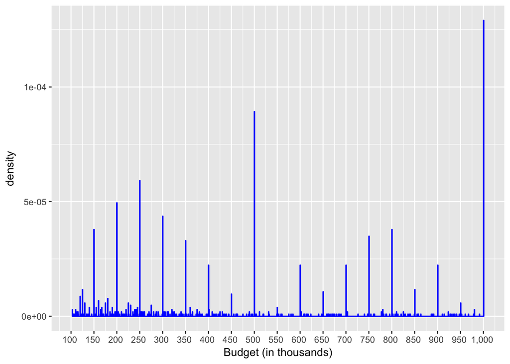

```r
#filtering out NA
#plotting only budget between $100,000 and $500,000
mydata <- filter (movies , movies$budget != 'NA')
mydata <- filter (mydata , mydata$budget >100000)
mydata <- filter (mydata , mydata$budget <= 1000000)

 ggplot(mydata, aes(budget )) +
 geom_histogram(binwidth=1000.5, boundry= 10, color = "blue", fill = "lightblue", aes(y=..density..) ) +
  scale_x_continuous(name = "Budget (in thousands)",labels=scales::unit_format(unit = "",1e-3),
    breaks = seq(100000, 1000000, 50000) )
```

4. Budget between : 1 MM and 7 MM :

Observe that the data is concentrated on round numbers of 0.5 MM. e.g 1MM , 1.5MM, till 7.0 MM.

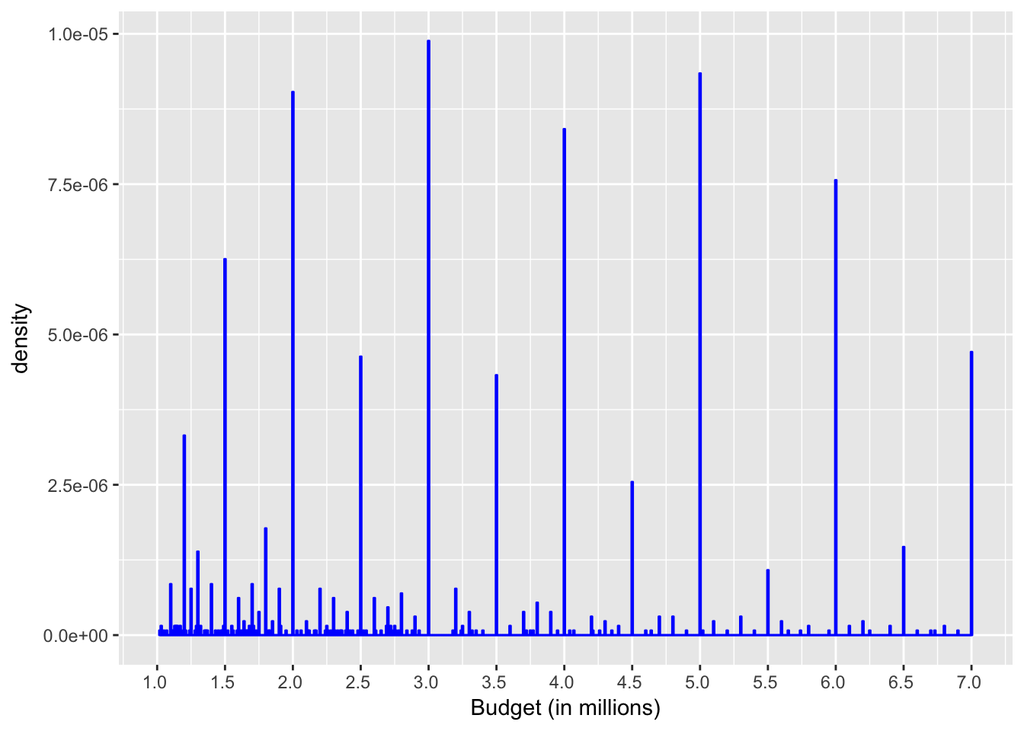

```r
#filtering out NA
#plotting only budget between $1,000,000 and $7,000,000
 mydata <- filter (movies , movies$budget != 'NA')
mydata <- filter (mydata , mydata$budget >1000000)
mydata <- filter (mydata , mydata$budget <= 7000000)

 ggplot(mydata, aes(budget )) +
 geom_histogram(binwidth=10000.5, boundry= 10, color = "blue", fill = "lightblue", aes(y=..density..) )+
  scale_x_continuous(name = "Budget (in millions)",labels=scales::unit_format(unit = "",1e-6),
    breaks = seq(1000000, 7000000, 500000) )
```

5. Budget between : 7 MM and 20 MM :

Observe that the data is concentrated on round numbers of 1.0 MM. e.g 8MM , 9MM.. till 20.0 MM.

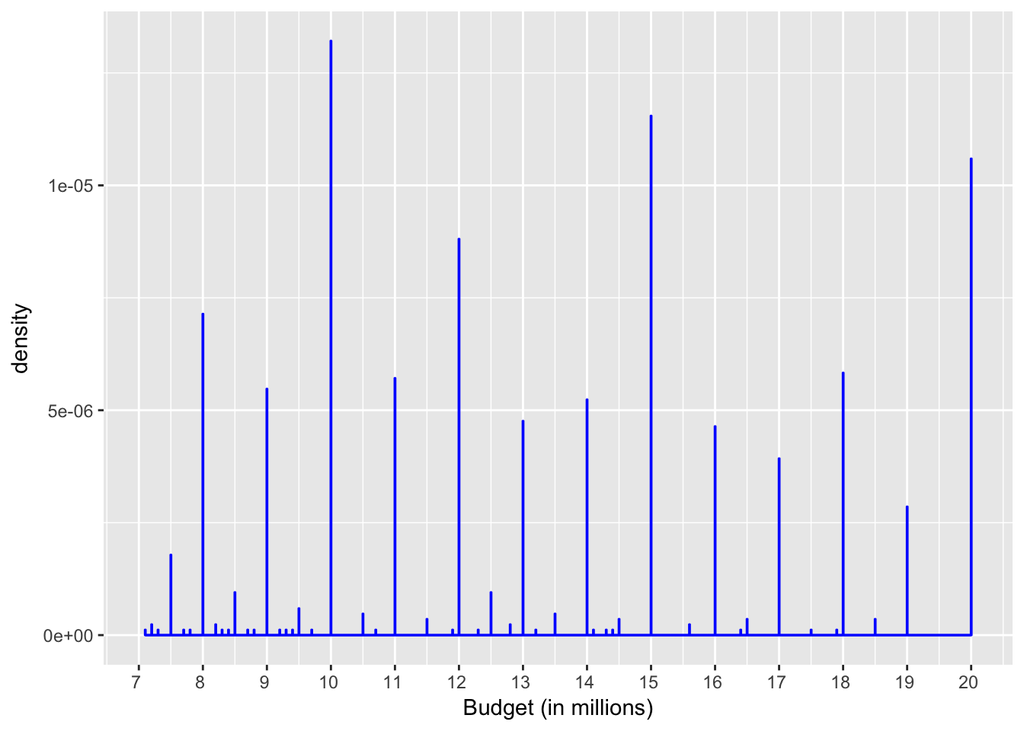

```r
#filtering out NA
#plotting only budget between $7,000,000 and $20,000,000
 mydata <- filter (movies , movies$budget != 'NA')
mydata <- filter (mydata , mydata$budget >7000000)
mydata <- filter (mydata , mydata$budget <= 20000000)

 ggplot(mydata, aes(budget )) +
 geom_histogram(binwidth=10000.5, boundry= 10, color = "blue", fill = "lightblue", aes(y=..density..) )+
  scale_x_continuous(name = "Budget (in millions)",labels=scales::unit_format(unit = "",1e-6),
    breaks = seq(7000000, 20000000, 1000000) )
```

### 4. Finches

1. Plot separate density histograms of the beak depth of the finches in *case0201* from the **Sleuth3** package, with density curves overlaid as on page 34 of the textbook. (However, do this by facetting on `Year` rather than using `grid.arrange`). [3 points]

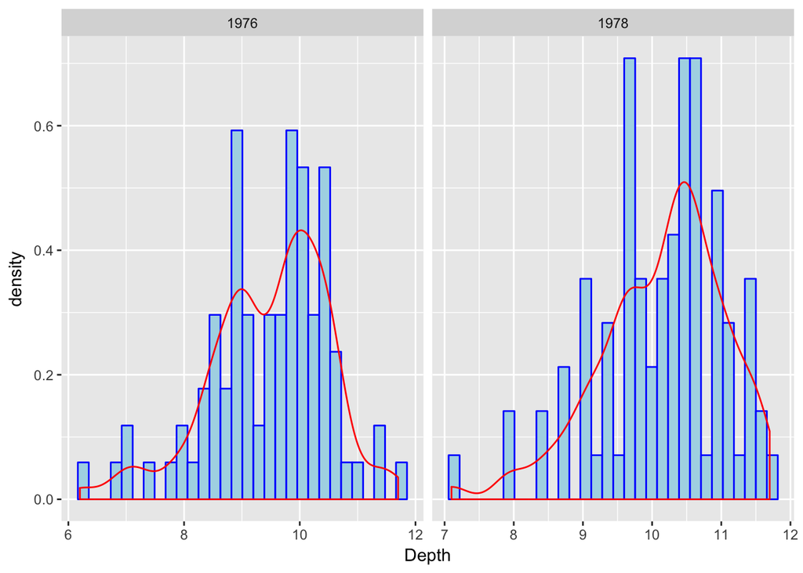

```r
  mydata <- case0201
  ggplot(mydata, aes(Depth )) +
  geom_histogram( color = "blue", fill = "lightblue",aes(y=..density..) )+
  geom_density(color = "red" , adjust = .75 ) +
  facet_wrap(~Year, scales = 'free_x')
```

2. Plot both density curves on the same graph to facilitate comparison. Make 1976 yellow and 1978 blue. Use alpha blending so the fills are transparent. [3 points]

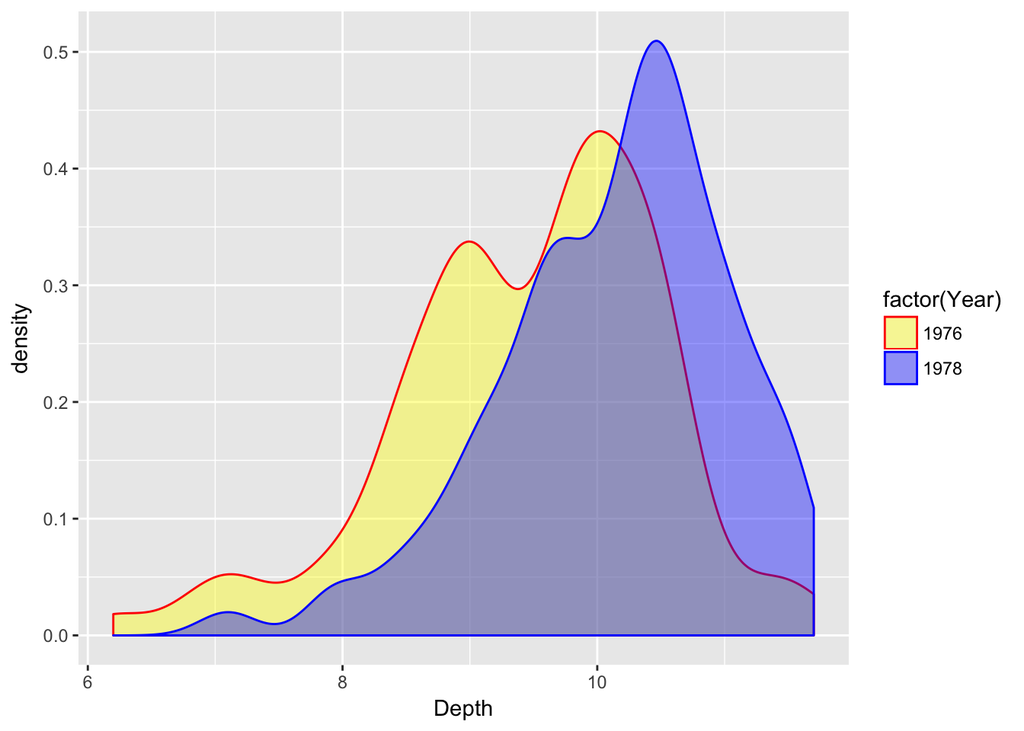

```r
ggplot(mydata, aes( x=Depth ,  fill=factor(Year), color=factor(Year) )) +
geom_density(  alpha = .4 ,adjust = .75) +
scale_fill_manual(values=c("yellow", "blue"))+
scale_color_manual(values=c("red", "blue"))
```

3. Based on your graphs in parts a) and b), describe how the distributions differ by year. [3 points]

*Answer :*

1. The distribution for year 1978 is shifted towards the right. This means the birds observed in this year had higher depth of beaks.
2. The distribution for year 1978 is more peaked compared to year 1976 . The peak in year 1978 is much more pronounced. This illustrates that most of the cases in year 1978 had more depth .
3. Curve for year 1976 is clearly bi-modal . While year 1978 can also be called also bi-modal but the mode on the left is considerable less pronounced as compared to year 1976.
4. What is the cause of the difference according to the information in the help file? [3 points]

*Answer :* As per the help file the cause of this difference can be attibuted to the draught in year 1977 . The hypotheseis presented in for this observation is that the only birds who could survive the draught were the ones that had bigger beaks . These beaks allowed than to crack the tough seeds that were available during the draught year to sustain them selves . This may be an evidence of the Darwanian theory of " Survial of the fittest " . Species adapt and evolve as per their environment and physical changes over many many years result in the evolution of new species.

### 5. Salary

Is the `Salary` variable in the *case0102* of **Sleuth3** normally distributed? Use two different graphical methods to provide evidence. [6 points]

*Answer*

Graph:1

The histogram and the density plot below show that the compared to the Normal distribution in Red , the Salary variable is bi-modal and does not fit closely on the normal distribution in Red . The Salary variable “weaves” around the red curve.

The genral shape is a bell shaped curve , hence we can say that it is approximatley normally distributed.

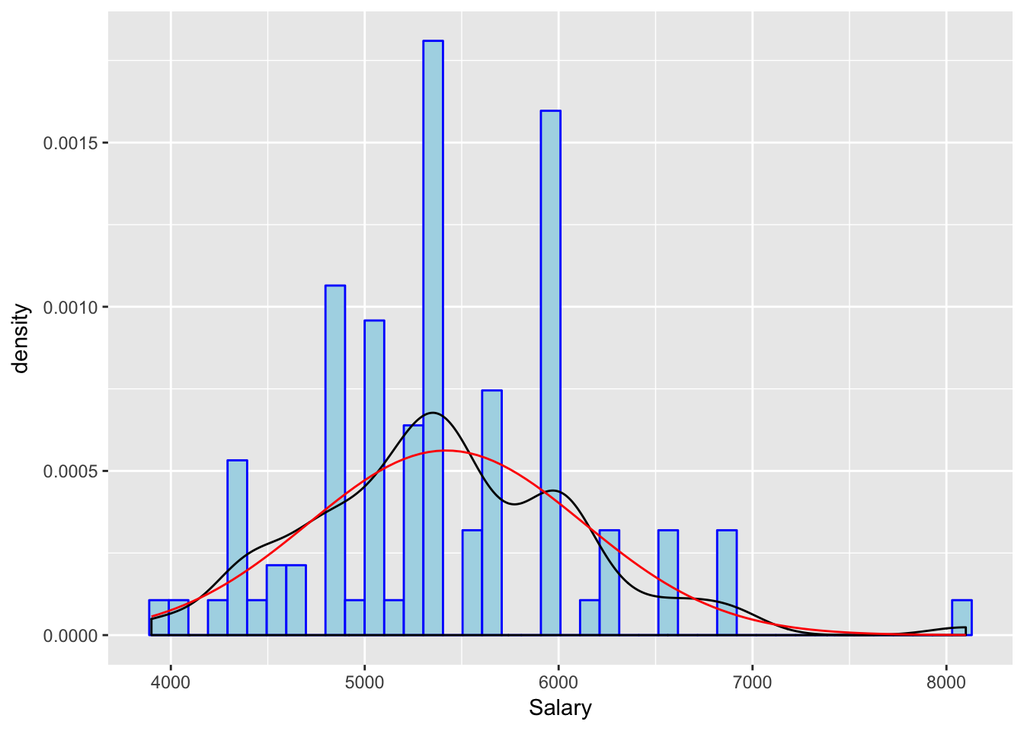

```r
mydata <- case0102

 ggplot(mydata, aes(Salary )) +
  geom_histogram( binwidth=101,color = "blue", fill = "lightblue",aes(y=..density..) )+
  geom_density( adjust = .7) +

  stat_function(fun=dnorm, args =list(mean(mydata$Salary), sd=sd(mydata$Salary)), color='red')
```

The Q-Q plot is close to a straight line . Hence the Salary variable is approximately Normally distributed.

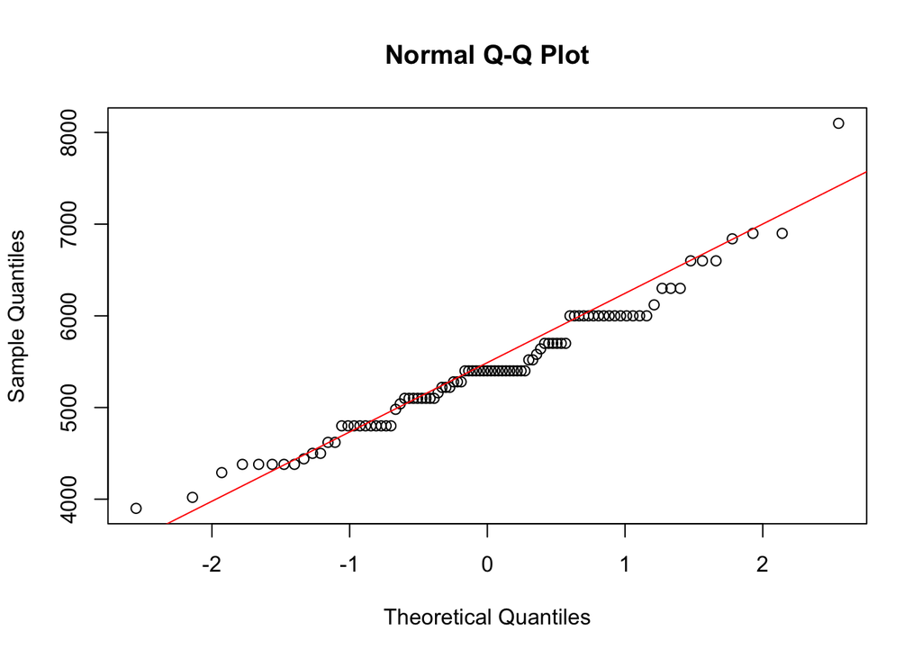

```r
qqnorm(mydata$Salary)
qqline(mydata$Salary, col="red")
```